# Capstone Analysis: Digital Banking Adoption

Tara

2026-06-14

# 1 Introduction

In this project, I explore the factors that may affect digital banking and mobile banking adoption. As banks continue to expand their digital services, it is important to understand why some customers use these services while others may be hesitant. To analyze the data, I use three analytical methods: classification models, clustering, and regression analysis. These methods help identify important factors related to adoption, group similar customers together, and predict digital banking engagement.

The dataset used for this project is stored in the following folder on my computer:

```r
data_folder <- "/Users/lj/Downloads/CAPSTONE"
data_folder
```

```
## [1] "/Users/lj/Downloads/CAPSTONE"
```

# 2 Load Packages

The code below loads the packages needed for the analysis. If a package is not already installed, the code installs it first.

```r
packages <- c(
  "tidyverse",
  "caret",
  "rpart",
  "rpart.plot",
  "factoextra",
  "cluster",
  "broom"
)

installed_packages <- rownames(installed.packages())

for(pkg in packages){
  if(!(pkg %in% installed_packages)){
    install.packages(pkg)
  }
  library(pkg, character.only = TRUE)
}
```

# 3 Import Data

The code below automatically finds the CSV file stored in the CAPSTONE folder and loads it into R so it can be used for the analysis.

```r
csv_files <- list.files(
  data_folder,
  pattern = "\\.csv$",
  full.names = TRUE
)

if(length(csv_files) == 0){
  stop("No CSV file was found in the CAPSTONE folder. Please save the dataset as a CSV file in that folder.")
}

banking <- read.csv(csv_files[1], stringsAsFactors = FALSE)

cat("File imported:", csv_files[1], "\n")
```

```
## File imported: /Users/lj/Downloads/CAPSTONE/Data Sheet V1.0.csv
```

```r
cat("Number of rows:", nrow(banking), "\n")
```

```
## Number of rows: 147
```

```r
cat("Number of columns:", ncol(banking), "\n")
```

```
## Number of columns: 92
```

# 4 Review Data Structure

Before running the models, I first review the dataset structure and column names. This helps me understand which variables are available and whether any adjustments are needed before analysis.

```r
str(banking)
```

```
## 'data.frame':    147 obs. of  92 variables:
##  $ ResNo      : int  61 1 3 4 5 10 11 12 15 18 ...
##  $ Gender     : int  2 2 1 1 2 1 1 1 2 1 ...
##  $ Race       : int  4 2 2 2 2 2 1 2 2 2 ...
##  $ AgeCat     : int  2 5 3 4 1 2 4 1 6 5 ...
##  $ CWrkStatus : int  4 3 2 2 1 2 2 2 5 4 ...
##  $ IncomeRng  : int  1 1 1 1 1 1 1 1 1 1 ...
##  $ HLvlEdu    : int  6 4 3 3 4 3 4 4 2 2 ...
##  $ BankAcc    : int  1 1 1 1 1 1 1 1 1 1 ...
##  $ NrBnkTym   : int  2 2 1 2 1 3 1 1 1 3 ...
##  $ AccessP1   : int  1 1 1 2 2 2 1 2 1 1 ...
##  $ AccessP2   : int  1 2 2 2 1 2 1 2 2 2 ...
##  $ AccessP3   : int  2 2 2 2 2 2 2 2 2 2 ...
##  $ AccessP4   : int  1 1 2 2 1 1 2 1 2 2 ...
##  $ AccessC1   : int  1 2 2 2 1 2 2 1 2 2 ...
```

[output cut: 78 more lines]

```r
names(banking)
```

```
##  [1] "ResNo"       "Gender"      "Race"        "AgeCat"      "CWrkStatus"
##  [6] "IncomeRng"   "HLvlEdu"     "BankAcc"     "NrBnkTym"    "AccessP1"
## [11] "AccessP2"    "AccessP3"    "AccessP4"    "AccessC1"    "AccessC2"
## [16] "AccessC3"    "AccessC4"    "BnkMBServ"   "MainMBPForm" "SU1"
## [21] "SU2"         "SU3"         "SU4"         "SU5"         "SU6"
## [26] "SU7"         "SU8"         "SU9"         "SU10"        "SU11"
## [31] "BPE1"        "BPE2"        "BPE3"        "BPE4"        "BEE1"
## [36] "BEE2"        "BEE3"        "BEE4"        "BSI1"        "BSI2"
## [41] "BSI3"        "BSI4"        "BPC1"        "BPC2"        "BPC3"
## [46] "BPC4"        "BPFC1"       "BPFC2"       "BPFC3"       "BPFC4"
## [51] "BFC1"        "BFC2"        "BFC3"        "BFC4"        "BPSE1"
## [56] "BPSE2"       "BPSE3"       "BPSE4"       "BBI1"        "BBI2"
## [61] "BBI3"        "CPE1"        "CPE2"        "CPE3"        "CPE4"
## [66] "CEE1"        "CEE2"        "CEE3"        "CEE4"        "CSI1"
## [71] "CSI2"        "CSI3"        "CSI4"        "CPC1"        "CPC2"
## [76] "CPC3"        "CPC4"        "CPFC1"       "CPFC2"       "CPFC3"
## [81] "CPFC4"       "CFC1"        "CFC2"        "CFC3"        "CFC4"
## [86] "CPSE1"       "CPSE2"       "CPSE3"       "CPSE4"       "CBI1"
## [91] "CBI2"        "CBI3"
```

```r
summary(banking)
```

```
##      ResNo           Gender           Race           AgeCat       CWrkStatus
##  Min.   :  1.0   Min.   :1.000   Min.   :1.000   Min.   :1.00   Min.   :1.000
##  1st Qu.: 50.5   1st Qu.:1.000   1st Qu.:2.000   1st Qu.:2.00   1st Qu.:1.000
##  Median :104.0   Median :1.000   Median :2.000   Median :3.00   Median :2.000
##  Mean   :105.0   Mean   :1.497   Mean   :2.313   Mean   :2.85   Mean   :1.884
##  3rd Qu.:155.5   3rd Qu.:2.000   3rd Qu.:2.000   3rd Qu.:3.50   3rd Qu.:2.000
##  Max.   :220.0   Max.   :2.000   Max.   :5.000   Max.   :6.00   Max.   :5.000
##
##    IncomeRng    HLvlEdu         BankAcc     NrBnkTym        AccessP1
##  Min.   :1   Min.   :1.000   Min.   :1   Min.   :1.000   Min.   :1.000
##  1st Qu.:1   1st Qu.:3.000   1st Qu.:1   1st Qu.:1.500   1st Qu.:1.000
##  Median :1   Median :4.000   Median :1   Median :2.000   Median :1.000
##  Mean   :1   Mean   :3.626   Mean   :1   Mean   :2.156   Mean   :1.252
##  3rd Qu.:1   3rd Qu.:4.000   3rd Qu.:1   3rd Qu.:3.000   3rd Qu.:1.500
##  Max.   :1   Max.   :6.000   Max.   :1   Max.   :3.000   Max.   :2.000
##
##     AccessP2        AccessP3        AccessP4        AccessC1
##  Min.   :1.000   Min.   :1.000   Min.   :1.000   Min.   :1.000
##  1st Qu.:1.000   1st Qu.:2.000   1st Qu.:1.000   1st Qu.:2.000
##  Median :2.000   Median :2.000   Median :2.000   Median :2.000
##  Mean   :1.653   Mean   :1.959   Mean   :1.653   Mean   :1.844
##  3rd Qu.:2.000   3rd Qu.:2.000   3rd Qu.:2.000   3rd Qu.:2.000
##  Max.   :2.000   Max.   :2.000   Max.   :2.000   Max.   :2.000
##
##     AccessC2        AccessC3        AccessC4       BnkMBServ
##  Min.   :1.000   Min.   :1.000   Min.   :1.000   Min.   :1.00
##  1st Qu.:2.000   1st Qu.:2.000   1st Qu.:1.000   1st Qu.:2.00
##  Median :2.000   Median :2.000   Median :2.000   Median :2.00
##  Mean   :1.973   Mean   :1.905   Mean   :1.707   Mean   :1.83
##  3rd Qu.:2.000   3rd Qu.:2.000   3rd Qu.:2.000   3rd Qu.:2.00
##  Max.   :2.000   Max.   :2.000   Max.   :2.000   Max.   :2.00
##
##   MainMBPForm          SU1              SU2              SU3
##  Min.   :0.0000   Min.   :0.0000   Min.   :0.0000   Min.   :0.0000
##  1st Qu.:0.0000   1st Qu.:0.0000   1st Qu.:0.0000   1st Qu.:0.0000
##  Median :0.0000   Median :0.0000   Median :0.0000   Median :0.0000
##  Mean   :0.2313   Mean   :0.5714   Mean   :0.5646   Mean   :0.6531
##  3rd Qu.:0.0000   3rd Qu.:0.0000   3rd Qu.:0.0000   3rd Qu.:0.0000
##  Max.   :3.0000   Max.   :5.0000   Max.   :5.0000   Max.   :5.0000
##
```

[output cut: 121 more lines]

```
##  Min.   :0.000   Min.   :0.000   Min.   :0.000   Min.   :0.000
##  1st Qu.:2.000   1st Qu.:1.000   1st Qu.:1.000   1st Qu.:1.000
##  Median :4.000   Median :2.000   Median :2.000   Median :2.000
##  Mean   :3.128   Mean   :2.021   Mean   :1.908   Mean   :1.943
##  3rd Qu.:4.000   3rd Qu.:3.000   3rd Qu.:3.000   3rd Qu.:2.000
##  Max.   :5.000   Max.   :5.000   Max.   :5.000   Max.   :5.000
##  NA's   :6       NA's   :6       NA's   :6       NA's   :6
##      CPSE3           CPSE4            CBI1            CBI2            CBI3
##  Min.   :0.000   Min.   :0.000   Min.   :0.000   Min.   :0.000   Min.   :0.00
##  1st Qu.:1.000   1st Qu.:1.000   1st Qu.:2.000   1st Qu.:3.000   1st Qu.:1.00
##  Median :2.000   Median :2.000   Median :3.000   Median :3.000   Median :2.00
##  Mean   :1.986   Mean   :2.156   Mean   :2.858   Mean   :3.113   Mean   :2.22
##  3rd Qu.:3.000   3rd Qu.:3.000   3rd Qu.:4.000   3rd Qu.:4.000   3rd Qu.:3.00
##  Max.   :5.000   Max.   :5.000   Max.   :5.000   Max.   :5.000   Max.   :5.00
##  NA's   :6       NA's   :6       NA's   :6       NA's   :6       NA's   :6
```

# 5 Data Cleaning

This section removes completely empty rows and converts character variables into factor variables. This helps prepare the dataset for the classification, clustering, and regression models.

```r
banking <- banking %>%
  filter(if_any(everything(), ~ !is.na(.)))

banking <- banking %>%
  mutate(across(where(is.character), as.factor))

# Remove respondent ID from modeling if it exists
if("ResNo" %in% names(banking)){
  banking_model <- banking %>% select(-ResNo)
} else {
  banking_model <- banking
}

str(banking_model)
```

```
## 'data.frame':    147 obs. of  91 variables:
##  $ Gender     : int  2 2 1 1 2 1 1 1 2 1 ...
##  $ Race       : int  4 2 2 2 2 2 1 2 2 2 ...
##  $ AgeCat     : int  2 5 3 4 1 2 4 1 6 5 ...
##  $ CWrkStatus : int  4 3 2 2 1 2 2 2 5 4 ...
##  $ IncomeRng  : int  1 1 1 1 1 1 1 1 1 1 ...
##  $ HLvlEdu    : int  6 4 3 3 4 3 4 4 2 2 ...
##  $ BankAcc    : int  1 1 1 1 1 1 1 1 1 1 ...
##  $ NrBnkTym   : int  2 2 1 2 1 3 1 1 1 3 ...
##  $ AccessP1   : int  1 1 1 2 2 2 1 2 1 1 ...
##  $ AccessP2   : int  1 2 2 2 1 2 1 2 2 2 ...
##  $ AccessP3   : int  2 2 2 2 2 2 2 2 2 2 ...
##  $ AccessP4   : int  1 1 2 2 1 1 2 1 2 2 ...
##  $ AccessC1   : int  1 2 2 2 1 2 2 1 2 2 ...
##  $ AccessC2   : int  1 2 2 2 2 2 2 2 2 2 ...
```

[output cut: 77 more lines]

# 6 Target Variable

For the classification analysis, the target variable should represent whether a customer uses or adopts mobile banking services. In this dataset, the variable `BnkMBServ` is used as the target variable because it appears to represent mobile banking service usage.

```r
adoption_column <- "BnkMBServ"

if(!(adoption_column %in% names(banking_model))){
  stop("The target variable BnkMBServ was not found in the dataset. Please check the column names.")
}

banking_model[[adoption_column]] <- as.factor(banking_model[[adoption_column]])

cat("Target Variable Used:", adoption_column, "\n")
```

```
## Target Variable Used: BnkMBServ
```

```r
table(banking_model[[adoption_column]])
```

```
##
##   1   2
##  25 122
```

# 7 Classification Models

The goal of the classification analysis is to predict whether a customer is likely to use mobile banking services. To accomplish this, I use logistic regression and decision tree models. These models help identify which customer characteristics and survey factors may be related to mobile banking adoption.

## 7.1 Prepare Data for Classification

For the initial classification models, I include the available variables except for the mobile banking service variable, which is the outcome being predicted. Some variables with only one value are removed because they do not help the model.

```r
classification_data <- banking_model %>%
  drop_na()

# Remove variables with only one unique value
classification_data <- classification_data %>%
  select(where(~ length(unique(.)) > 1))

# Make sure the target variable is still included
if(!(adoption_column %in% names(classification_data))){
  stop("The adoption target variable was removed during cleaning. Please review the dataset.")
}

# Remove outcome levels with very small counts if needed
classification_data[[adoption_column]] <- droplevels(as.factor(classification_data[[adoption_column]]))

cat("Classification data rows:", nrow(classification_data), "\n")
```

```
## Classification data rows: 140
```

```r
cat("Target variable distribution:\n")
```

```
## Target variable distribution:
```

```r
print(table(classification_data[[adoption_column]]))
```

```
##
##   1   2
##  19 121
```

## 7.2 Train and Test Split

The dataset is split into training and testing data. The training data is used to build the models, while the testing data is used to evaluate how well the models perform on data they have not seen before.

```r
set.seed(123)

if(length(unique(classification_data[[adoption_column]])) < 2){
  stop("The target variable has fewer than two classes, so classification models cannot be created.")
}

train_index <- createDataPartition(
  classification_data[[adoption_column]],
  p = 0.70,
  list = FALSE
)

train_data <- classification_data[train_index, ]
test_data <- classification_data[-train_index, ]

cat("Training rows:", nrow(train_data), "\n")
```

```
## Training rows: 99
```

```r
cat("Testing rows:", nrow(test_data), "\n")
```

```
## Testing rows: 41
```

## 7.3 Logistic Regression

Logistic regression is used to examine the relationship between the predictors and mobile banking usage. To keep the model stable, this section uses survey response variables that are numeric or can be treated as numeric.

```r
# Create a safer dataset for logistic regression using numeric predictors only
log_data <- classification_data %>%
  mutate(across(everything(), ~ suppressWarnings(as.numeric(as.character(.)))))

# Add target back as factor from original classification data
log_data[[adoption_column]] <- classification_data[[adoption_column]]

# Remove columns that became all NA, except target
log_data <- log_data %>%
  select(where(~ !all(is.na(.))))

# Remove rows with missing values
log_data <- log_data %>% drop_na()

# Keep only predictors and target
predictors <- setdiff(names(log_data), adoption_column)

# Limit predictors if dataset has many columns to avoid model problems
preferred_predictors <- c(
  "AgeCat", "IncomeRng", "HLvlEdu", "BankAcc", "NrBnkTym",
  "AccessP1", "AccessP2", "AccessP3", "AccessP4",
  "AccessC1", "AccessC2", "AccessC3", "AccessC4",
  "SU1", "SU2", "SU3", "SU4", "SU5", "SU6", "SU7", "SU8", "SU9", "SU10", "SU11",
  "BPE1", "BPE2", "BPE3", "BPE4",
  "BEE1", "BEE2", "BEE3", "BEE4",
  "BSI1", "BSI2", "BSI3", "BSI4"
)

model_predictors <- intersect(preferred_predictors, predictors)

if(length(model_predictors) < 2){
  model_predictors <- predictors[1:min(10, length(predictors))]
}

log_formula <- as.formula(
  paste(adoption_column, "~", paste(model_predictors, collapse = " + "))
)

set.seed(123)
log_train_index <- createDataPartition(log_data[[adoption_column]], p = 0.70, list = FALSE)
log_train <- log_data[log_train_index, ]
log_test <- log_data[-log_train_index, ]

log_model <- glm(
  log_formula,
  data = log_train,
  family = binomial
)

summary(log_model)
```

```
##
## Call:
## glm(formula = log_formula, family = binomial, data = log_train)
##
## Coefficients: (10 not defined because of singularities)
##               Estimate Std. Error z value Pr(>|z|)
## (Intercept) -1.125e+02  1.392e+06   0.000        1
## AgeCat       1.542e-01  3.431e+04   0.000        1
## HLvlEdu      2.236e-01  3.452e+04   0.000        1
## NrBnkTym     1.102e-01  5.591e+04   0.000        1
## AccessP1     4.344e+01  4.054e+05   0.000        1
## AccessP2    -3.856e+00  3.873e+05   0.000        1
## AccessP3     2.300e+00  2.691e+05   0.000        1
## AccessP4     1.171e+00  1.128e+05   0.000        1
## AccessC1    -3.264e-01  1.413e+05   0.000        1
## AccessC2    -6.907e-01  3.714e+05   0.000        1
## AccessC3     4.902e+01  9.348e+04   0.001        1
## AccessC4    -7.959e-01  1.021e+05   0.000        1
## SU1          4.183e+02  5.529e+06   0.000        1
## SU2         -2.994e+02  3.868e+06   0.000        1
## SU3         -7.786e+01  7.853e+05   0.000        1
## SU4          2.688e+02  3.294e+06   0.000        1
## SU5         -1.512e+02  1.910e+06   0.000        1
## SU6                 NA         NA      NA       NA
## SU7          6.042e+01  8.096e+05   0.000        1
## SU8         -7.539e+01  1.005e+06   0.000        1
## SU9         -2.099e-01  1.340e+05   0.000        1
## SU10         4.411e+01  6.765e+05   0.000        1
## SU11        -1.160e+02  1.608e+06   0.000        1
## BPE1         4.033e+02  5.594e+06   0.000        1
## BPE2        -3.439e+02  4.103e+06   0.000        1
## BPE3        -1.782e+02  3.280e+06   0.000        1
## BPE4                NA         NA      NA       NA
## BEE1                NA         NA      NA       NA
## BEE2                NA         NA      NA       NA
## BEE3                NA         NA      NA       NA
## BEE4                NA         NA      NA       NA
## BSI1                NA         NA      NA       NA
## BSI2                NA         NA      NA       NA
## BSI3                NA         NA      NA       NA
## BSI4                NA         NA      NA       NA
##
## (Dispersion parameter for binomial family taken to be 1)
##
##     Null deviance: 8.0689e+01  on 98  degrees of freedom
## Residual deviance: 9.9364e-10  on 74  degrees of freedom
## AIC: 50
##
## Number of Fisher Scoring iterations: 25
```

## 7.4 Logistic Regression Accuracy

This section evaluates the logistic regression model by comparing the predicted classes to the actual classes in the test data.

```r
# This works best when the target variable has two classes
if(length(levels(log_train[[adoption_column]])) == 2){
  positive_class <- levels(log_train[[adoption_column]])[2]
  negative_class <- levels(log_train[[adoption_column]])[1]

  log_prob <- predict(log_model, newdata = log_test, type = "response")
  log_pred <- ifelse(log_prob >= 0.5, positive_class, negative_class)
  log_pred <- factor(log_pred, levels = levels(log_test[[adoption_column]]))

  confusionMatrix(log_pred, log_test[[adoption_column]])
} else {
  cat("Logistic regression accuracy table was skipped because the target variable has more than two classes.\n")
}
```

```
## Confusion Matrix and Statistics
##
##           Reference
## Prediction  1  2
##          1  3  3
##          2  2 33
##
##                Accuracy : 0.878
##                  95% CI : (0.738, 0.9592)
##     No Information Rate : 0.878
##     P-Value [Acc > NIR] : 0.6162
##
##                   Kappa : 0.4757
##
##  Mcnemar's Test P-Value : 1.0000
##
##             Sensitivity : 0.60000
##             Specificity : 0.91667
##          Pos Pred Value : 0.50000
##          Neg Pred Value : 0.94286
##              Prevalence : 0.12195
##          Detection Rate : 0.07317
##    Detection Prevalence : 0.14634
##       Balanced Accuracy : 0.75833
##
##        'Positive' Class : 1
##
```

## 7.5 Decision Tree Model

The decision tree model provides a visual way to understand how different factors may contribute to mobile banking usage. This can make the results easier to interpret compared to some other models.

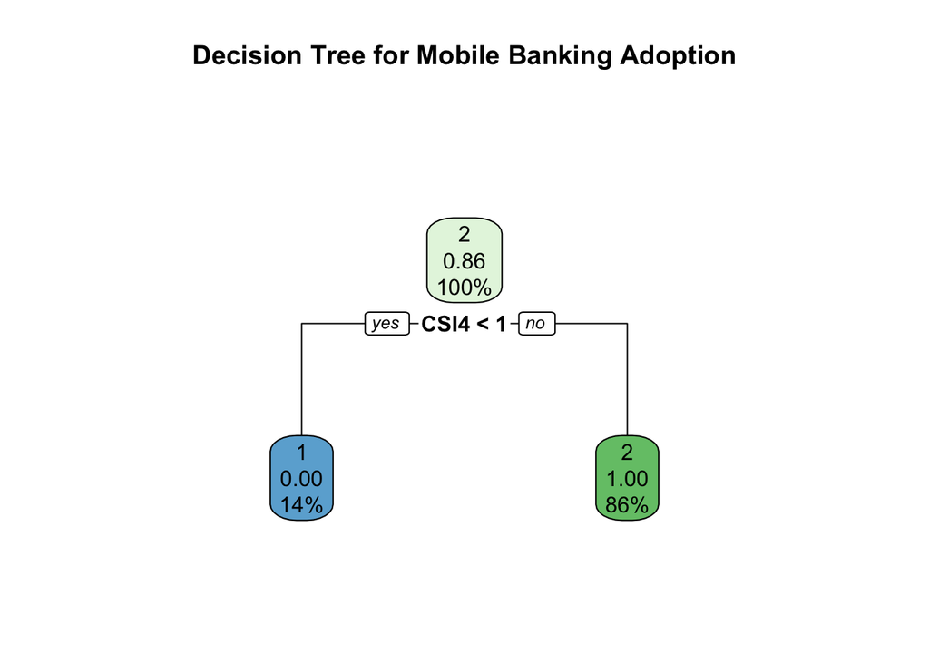

```r
tree_formula <- as.formula(
  paste(adoption_column, "~ .")
)

tree_model <- rpart(
  tree_formula,
  data = train_data,
  method = "class",
  control = rpart.control(cp = 0.01)
)

rpart.plot(tree_model, main = "Decision Tree for Mobile Banking Adoption")
```

## 7.6 Decision Tree Accuracy

```r
tree_pred <- predict(tree_model, newdata = test_data, type = "class")
confusionMatrix(tree_pred, test_data[[adoption_column]])
```

```
## Confusion Matrix and Statistics
##
##           Reference
## Prediction  1  2
##          1  5  1
##          2  0 35
##
##                Accuracy : 0.9756
##                  95% CI : (0.8714, 0.9994)
##     No Information Rate : 0.878
##     P-Value [Acc > NIR] : 0.03236
##
##                   Kappa : 0.8951
##
##  Mcnemar's Test P-Value : 1.00000
##
##             Sensitivity : 1.0000
##             Specificity : 0.9722
##          Pos Pred Value : 0.8333
##          Neg Pred Value : 1.0000
##              Prevalence : 0.1220
##          Detection Rate : 0.1220
##    Detection Prevalence : 0.1463
##       Balanced Accuracy : 0.9861
##
##        'Positive' Class : 1
##
```

## 7.7 Classification Interpretation

The classification models help identify the factors that may influence digital banking adoption. Logistic regression is used to examine the relationship between customer characteristics and adoption, while the decision tree provides an easy-to-understand visual representation of how different factors contribute to adoption decisions. Together, these models help explain customer behavior and highlight the variables that may be important in predicting mobile banking usage.

# 8 Clustering Analysis

The goal of clustering is to group customers based on similarities in their digital banking usage, attitudes, and demographic characteristics. By identifying these groups, I can better understand the different types of customers in the dataset and how they interact with digital banking services. The resulting segments may include highly engaged digital users, hesitant users, low-tech users, or customers with stronger security concerns.

## 8.1 Prepare Data for Clustering

Since clustering works with numeric data, this code selects numeric variables from the dataset. The mobile banking service target variable is removed from the clustering analysis so that customers are grouped based on their characteristics rather than the outcome being analyzed.

```r
cluster_data <- banking_model %>%
  select(-any_of(adoption_column)) %>%
  mutate(across(everything(), ~ suppressWarnings(as.numeric(as.character(.))))) %>%
  select(where(~ !all(is.na(.)))) %>%
  drop_na()

# Remove variables with no variation
cluster_data <- cluster_data %>%
  select(where(~ sd(., na.rm = TRUE) > 0))

cat("Rows used for clustering:", nrow(cluster_data), "\n")
```

```
## Rows used for clustering: 140
```

```r
cat("Variables used for clustering:", ncol(cluster_data), "\n")
```

```
## Variables used for clustering: 88
```

## 8.2 Standardize Variables

The clustering variables are standardized so that variables measured on different scales can be compared fairly.

```r
cluster_scaled <- scale(cluster_data)
```

## 8.3 K-Means Clustering

For this analysis, I use four clusters to represent four potential customer segments. The goal is to identify groups of customers who share similar characteristics, behaviors, and attitudes toward digital banking.

```r
set.seed(123)

kmeans_model <- kmeans(
  cluster_scaled,
  centers = 4,
  nstart = 25
)

cluster_results <- cluster_data %>%
  mutate(Cluster = as.factor(kmeans_model$cluster))

table(cluster_results$Cluster)
```

```
##
##  1  2  3  4
## 18 33 35 54
```

## 8.4 Cluster Visualization

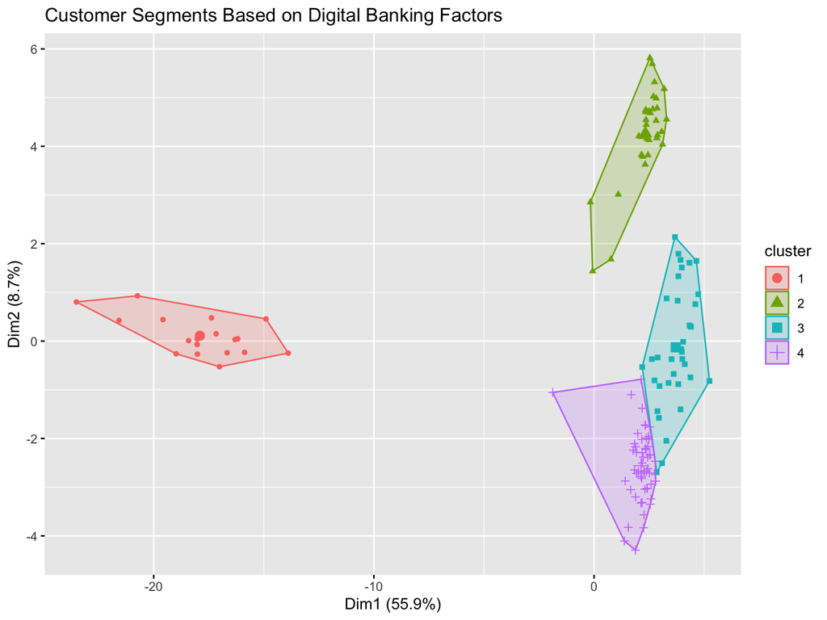

```r
fviz_cluster(
  kmeans_model,
  data = cluster_scaled,
  geom = "point",
  main = "Customer Segments Based on Digital Banking Factors"
)
```

## 8.5 Cluster Profiles

The table below shows the average values for each cluster. These averages can be used to describe each customer segment.

```r
cluster_profiles <- cluster_results %>%
  group_by(Cluster) %>%
  summarise(across(everything(), mean, na.rm = TRUE))

cluster_profiles
```

```
## # A tibble: 4 × 89
##   Cluster Gender  Race AgeCat CWrkStatus HLvlEdu NrBnkTym AccessP1 AccessP2
##   <fct>    <dbl> <dbl>  <dbl>      <dbl>   <dbl>    <dbl>    <dbl>    <dbl>
## 1 1         1.56  2.5    2.11       1.72    4.17     1.67     1.33     1.28
## 2 2         1.52  2.33   3.21       1.97    4.06     2.15     1.06     1.64
## 3 3         1.43  2.2    3.29       2.11    3.97     1.71     1.37     1.57
## 4 4         1.46  2.31   2.61       1.65    2.76     2.61     1.28     1.85
## # ℹ 80 more variables: AccessP3 <dbl>, AccessP4 <dbl>, AccessC1 <dbl>,
## #   AccessC2 <dbl>, AccessC3 <dbl>, AccessC4 <dbl>, MainMBPForm <dbl>,
## #   SU1 <dbl>, SU2 <dbl>, SU3 <dbl>, SU4 <dbl>, SU5 <dbl>, SU6 <dbl>,
## #   SU7 <dbl>, SU8 <dbl>, SU9 <dbl>, SU10 <dbl>, SU11 <dbl>, BPE1 <dbl>,
## #   BPE2 <dbl>, BPE3 <dbl>, BPE4 <dbl>, BEE1 <dbl>, BEE2 <dbl>, BEE3 <dbl>,
## #   BEE4 <dbl>, BSI1 <dbl>, BSI2 <dbl>, BSI3 <dbl>, BSI4 <dbl>, BPC1 <dbl>,
## #   BPC2 <dbl>, BPC3 <dbl>, BPC4 <dbl>, BPFC1 <dbl>, BPFC2 <dbl>, …
```

## 8.6 Clustering Interpretation

The clustering analysis groups customers into four segments based on similarities in their responses. After reviewing the cluster profiles, each group can be interpreted and assigned a meaningful description. For example, one cluster may represent highly digital users, while another may represent customers who are hesitant or more concerned about security. These segments can help banks better understand customer needs and design more targeted digital banking support.

# 9 Regression Analysis

Regression analysis is used to examine how customer characteristics relate to digital banking engagement levels. This approach helps identify which factors may have the greatest impact on customer usage and engagement with digital banking services.

In this dataset, the variables `BBI1`, `BBI2`, and `BBI3` appear to represent behavioral intention or banking behavior intention items. I create an average behavioral intention score and use it as the outcome variable for regression analysis.

## 9.1 Create Regression Outcome

```r
bbi_vars <- c("BBI1", "BBI2", "BBI3")
available_bbi_vars <- intersect(bbi_vars, names(banking_model))

if(length(available_bbi_vars) == 0){
  stop("No BBI variables were found for the regression outcome.")
}

regression_data <- banking_model %>%
  mutate(across(all_of(available_bbi_vars), ~ suppressWarnings(as.numeric(as.character(.))))) %>%
  mutate(Digital_Engagement_Score = rowMeans(across(all_of(available_bbi_vars)), na.rm = TRUE))

summary(regression_data$Digital_Engagement_Score)
```

```
##    Min. 1st Qu.  Median    Mean 3rd Qu.    Max.
##   0.000   0.000   0.000   0.263   0.000   3.000
```

## 9.2 Prepare Regression Predictors

```r
regression_data <- regression_data %>%
  select(-any_of(c(adoption_column, available_bbi_vars))) %>%
  mutate(across(everything(), ~ suppressWarnings(as.numeric(as.character(.))))) %>%
  select(where(~ !all(is.na(.)))) %>%
  mutate(Digital_Engagement_Score = banking_model %>%
           mutate(across(all_of(available_bbi_vars), ~ suppressWarnings(as.numeric(as.character(.))))) %>%
           transmute(score = rowMeans(across(all_of(available_bbi_vars)), na.rm = TRUE)) %>%
           pull(score)) %>%
  drop_na()

# Remove variables with no variation
regression_data <- regression_data %>%
  select(where(~ sd(., na.rm = TRUE) > 0))

cat("Rows used for regression:", nrow(regression_data), "\n")
```

```
## Rows used for regression: 140
```

```r
cat("Variables used for regression:", ncol(regression_data), "\n")
```

```
## Variables used for regression: 86
```

## 9.3 Linear Regression Model

```r
reg_predictors <- setdiff(names(regression_data), "Digital_Engagement_Score")

preferred_reg_predictors <- c(
  "AgeCat", "IncomeRng", "HLvlEdu", "BankAcc", "NrBnkTym",
  "AccessP1", "AccessP2", "AccessP3", "AccessP4",
  "AccessC1", "AccessC2", "AccessC3", "AccessC4",
  "SU1", "SU2", "SU3", "SU4", "SU5", "SU6", "SU7", "SU8", "SU9", "SU10", "SU11",
  "BPE1", "BPE2", "BPE3", "BPE4",
  "BEE1", "BEE2", "BEE3", "BEE4",
  "BSI1", "BSI2", "BSI3", "BSI4"
)

reg_model_predictors <- intersect(preferred_reg_predictors, reg_predictors)

if(length(reg_model_predictors) < 2){
  reg_model_predictors <- reg_predictors[1:min(10, length(reg_predictors))]
}

reg_formula <- as.formula(
  paste("Digital_Engagement_Score ~", paste(reg_model_predictors, collapse = " + "))
)

reg_model <- lm(
  reg_formula,
  data = regression_data
)

summary(reg_model)
```

```
##
## Call:
## lm(formula = reg_formula, data = regression_data)
##
## Residuals:
##        Min         1Q     Median         3Q        Max
## -3.841e-15 -2.397e-16  0.000e+00  2.229e-16  2.653e-15
##
## Coefficients: (5 not defined because of singularities)
##               Estimate Std. Error    t value Pr(>|t|)
## (Intercept) -2.651e-15  1.265e-15 -2.095e+00 0.038438 *
## AgeCat       1.502e-16  6.255e-17  2.401e+00 0.018023 *
## HLvlEdu     -5.418e-17  6.738e-17 -8.040e-01 0.423061
## NrBnkTym     2.428e-16  9.673e-17  2.510e+00 0.013525 *
## AccessP1    -2.413e-16  1.786e-16 -1.351e+00 0.179390
## AccessP2     2.350e-16  1.637e-16  1.436e+00 0.153955
## AccessP3    -1.467e-15  3.584e-16 -4.093e+00 8.15e-05 ***
## AccessP4    -3.556e-16  1.686e-16 -2.110e+00 0.037167 *
## AccessC1    -9.200e-17  2.271e-16 -4.050e-01 0.686173
## AccessC2     3.186e-15  5.788e-16  5.504e+00 2.45e-07 ***
## AccessC3    -9.760e-16  2.996e-16 -3.258e+00 0.001492 **
## AccessC4     6.379e-16  1.731e-16  3.685e+00 0.000357 ***
## SU1          5.145e-01  1.609e-15  3.198e+14  < 2e-16 ***
## SU2         -5.520e-01  2.287e-15 -2.413e+14  < 2e-16 ***
## SU3         -1.246e-01  1.290e-15 -9.658e+13  < 2e-16 ***
## SU4          1.583e-01  7.082e-16  2.235e+14  < 2e-16 ***
## SU5          2.011e+00  3.215e-15  6.254e+14  < 2e-16 ***
## SU6         -8.004e-01  2.294e-15 -3.489e+14  < 2e-16 ***
## SU7          1.424e-01  8.831e-16  1.613e+14  < 2e-16 ***
## SU8         -6.625e-01  1.927e-15 -3.438e+14  < 2e-16 ***
## SU9         -7.100e-01  1.949e-15 -3.642e+14  < 2e-16 ***
## SU10         5.479e-01  1.602e-15  3.420e+14  < 2e-16 ***
## SU11         1.071e+00  2.152e-15  4.979e+14  < 2e-16 ***
## BPE1         1.289e-01  5.287e-16  2.438e+14  < 2e-16 ***
## BPE2        -2.102e-02  1.676e-15 -1.254e+13  < 2e-16 ***
## BPE3         3.498e+00  4.970e-15  7.037e+14  < 2e-16 ***
## BPE4        -3.568e+00  5.822e-15 -6.128e+14  < 2e-16 ***
## BEE1         1.444e+00  4.082e-15  3.537e+14  < 2e-16 ***
## BEE2        -2.507e+00  7.713e-15 -3.250e+14  < 2e-16 ***
## BEE3        -1.225e+00  5.208e-15 -2.352e+14  < 2e-16 ***
## BEE4                NA         NA         NA       NA
## BSI1                NA         NA         NA       NA
## BSI2                NA         NA         NA       NA
## BSI3                NA         NA         NA       NA
## BSI4                NA         NA         NA       NA
## ---
## Signif. codes:  0 '***' 0.001 '**' 0.01 '*' 0.05 '.' 0.1 ' ' 1
##
## Residual standard error: 7.377e-16 on 110 degrees of freedom
## Multiple R-squared:      1,  Adjusted R-squared:      1
## F-statistic: 3.381e+30 on 29 and 110 DF,  p-value: < 2.2e-16
```

## 9.4 Regression Visualization

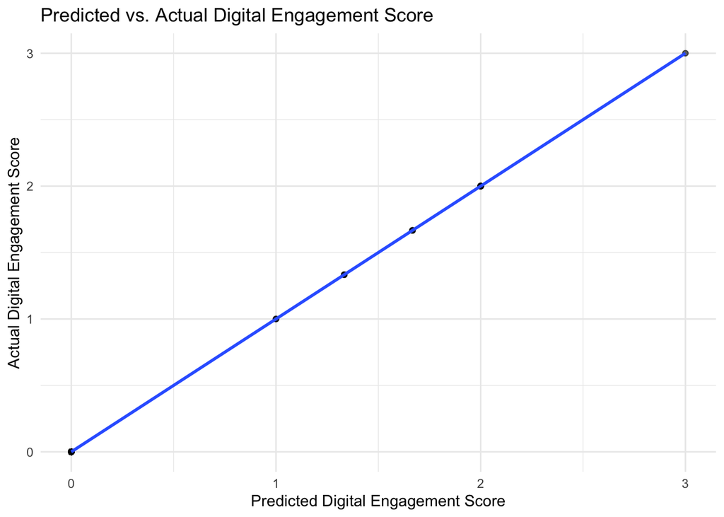

```r
regression_data$Predicted_Engagement <- predict(reg_model, newdata = regression_data)

ggplot(regression_data, aes(x = Predicted_Engagement, y = Digital_Engagement_Score)) +
  geom_point(alpha = 0.6) +
  geom_smooth(method = "lm", se = FALSE) +
  labs(
    title = "Predicted vs. Actual Digital Engagement Score",
    x = "Predicted Digital Engagement Score",
    y = "Actual Digital Engagement Score"
  ) +
  theme_minimal()
```

## 9.5 Regression Interpretation

The regression model helps explain which factors may be related to digital engagement levels. By reviewing the model results, I can identify which variables have stronger relationships with the digital engagement score. This analysis provides insight into the factors that may influence how likely customers are to continue using or engaging with mobile banking services.

# 10 Export Data for Tableau

Later, I plan to create Tableau dashboards to visualize adoption trends, customer segments, and digital engagement patterns. The code below saves a cleaned version of the data and the cluster results so they can be used in Tableau.

```r
output_folder <- data_folder

write.csv(
  banking_model,
  file.path(output_folder, "cleaned_banking_data_for_tableau.csv"),
  row.names = FALSE
)

write.csv(
  cluster_results,
  file.path(output_folder, "customer_clusters_for_tableau.csv"),
  row.names = FALSE
)

cat("Files saved for Tableau in:", output_folder)
```

```
## Files saved for Tableau in: /Users/lj/Downloads/CAPSTONE
```

# 11 Conclusion

In this project, I used classification, clustering, and regression techniques to analyze factors related to digital banking adoption. The classification models were used to predict mobile banking usage, the clustering analysis grouped customers into meaningful segments, and the regression model examined factors related to digital engagement. Overall, these methods helped identify patterns in customer behavior and provided insights that may help financial institutions better understand digital banking adoption and customer needs.